# Python Code Public Examples

# Pruning Trees

Pruning is a technique used to reduce the complexity of a decision tree by removing parts of the tree that do not provide much predictive power. Pruning helps:

Prevent Overfitting: By simplifying the tree, we avoid learning noise in the training data. Improve Generalization: A pruned tree performs better on unseen data by reducing variance. Decision Tree Analysis Depth: The Decision Tree was explicitly restricted to a maximum depth of 3, which is a form of pre-pruning (limiting the tree's growth upfront).

With this restriction, the tree is already "pruned" to prevent overfitting. There’s no need for post-pruning since we constrained its growth effectively. Leaf Nodes:

Each leaf has a reasonable distribution of samples, indicating that the splits provide meaningful predictive power.

Random Forest Analysis Individual Trees:

Random Forest combines multiple Decision Trees, and each tree is typically unpruned by default. However, in our case, the trees in the Random Forest were also restricted to a depth of 3 (via max_depth=3), effectively pruning them during training. Need for Pruning:

Random Forest does not require explicit pruning because it relies on combining predictions from many weak learners (trees) to achieve robust performance. Further pruning individual trees in Random Forest is unnecessary and counterproductive, as it could reduce the diversity of the ensemble.

Conclusion For the Decision Tree: No additional pruning is needed because we already applied pre-pruning with max_depth=3.

For the Random Forest: No pruning is needed since the ensemble method naturally mitigates overfitting through averaging.

# Bonus Task: Train and Evaluate Deeper or Unpruned Trees

To analyze whether deeper or unpruned trees provide any benefits, we can:

Increase max_depth: Allow the trees to grow deeper to see if performance improves. Train Without Depth Restriction: Remove the depth limit and observe if overfitting occurs.

```python
# Train a deeper Decision Tree (no max_depth restriction)
deeper_dt_model = DecisionTreeClassifier(
    random_state=1  # No depth restriction
)

deeper_dt_model.fit(X_train, y_train)

# Evaluate the deeper Decision Tree
y_pred_deeper_dt = deeper_dt_model.predict(X_test)

accuracy_deeper_dt = accuracy_score(y_test, y_pred_deeper_dt)
print("Deeper Decision Tree Accuracy:", accuracy_deeper_dt)
print("\nClassification Report:\n", classification_report(y_test, y_pred_deeper_dt))
```

```
Deeper Decision Tree Accuracy: 0.7955202312138728

Classification Report:
               precision    recall  f1-score   support

           0       0.86      0.84      0.85       971
           1       0.65      0.69      0.67       413

    accuracy                           0.80      1384
   macro avg       0.76      0.76      0.76      1384
weighted avg       0.80      0.80      0.80      1384
```

# Key Observations:

No Improvement:

Pre-pruning (max_depth=3) was sufficient for the Decision Tree. Allowing deeper splits only increases model complexity without improving generalization.

```python
# Train a Random Forest without depth restriction
deeper_rf_model = RandomForestClassifier(
    n_estimators=100,  # Number of trees
    random_state=1,  # For reproducibility
    class_weight='balanced'  # To handle class imbalance
)

# Fit the model on the training data
deeper_rf_model.fit(X_train, y_train)

# Make predictions on the test data
y_pred_deeper_rf = deeper_rf_model.predict(X_test)

# Evaluate the deeper Random Forest
accuracy_deeper_rf = accuracy_score(y_test, y_pred_deeper_rf)
print("Deeper Random Forest Accuracy:", accuracy_deeper_rf)
print("\nClassification Report:\n", classification_report(y_test, y_pred_deeper_rf))
```

```
Deeper Random Forest Accuracy: 0.8526011560693642

Classification Report:
               precision    recall  f1-score   support

           0       0.88      0.91      0.90       971
           1       0.78      0.71      0.74       413

    accuracy                           0.85      1384
   macro avg       0.83      0.81      0.82      1384
weighted avg       0.85      0.85      0.85      1384
```

# Analysis of Deeper Random Forest Results

Improved Accuracy:

The deeper Random Forest handles class imbalance better than the Decision Tree. The improvement in precision for Class 1 indicates that the deeper Random Forest captures some additional patterns, but recall did not improve significantly. Potential Risks:

While the deeper Random Forest shows better performance, there is a slight risk of overfitting due to the increased complexity. This is mitigated by the ensemble nature of Random Forest.

Conclusion For the Random Forest, removing the depth restriction slightly improves accuracy and precision, particularly for Class 1. However, the performance gain is marginal, suggesting that the max_depth=3 setting was already close to optimal in balancing bias and variance.

```python
# Initialize the XGBoost model
xgb_model = XGBClassifier(
    max_depth=3,  # Same depth as previous models for fair comparison
    n_estimators=100,  # Number of boosting rounds
    learning_rate=0.1,  # Learning rate
    use_label_encoder=False,  # Suppress warnings
    eval_metric="logloss",  # Evaluation metric
    random_state=1
)

# Train the Gradient Boosting model
xgb_model.fit(X_train, y_train)

# Make predictions on the test data
y_pred_xgb = xgb_model.predict(X_test)

# Evaluate the Gradient Boosting model
xgb_accuracy = accuracy_score(y_test, y_pred_xgb)
print("Gradient Boosting Classifier Accuracy:", xgb_accuracy)
print("\nClassification Report:\n", classification_report(y_test, y_pred_xgb))
```

```
Gradient Boosting Classifier Accuracy: 0.861271676300578

Classification Report:
               precision    recall  f1-score   support

           0       0.89      0.91      0.90       971
           1       0.78      0.74      0.76       413

    accuracy                           0.86      1384
   macro avg       0.84      0.83      0.83      1384
weighted avg       0.86      0.86      0.86      1384
```

# Bonus Task - Gradient Boosting Model Performance Analysis

The Gradient Boosting model outperformed both the Decision Tree and Random Forest models. Here’s the detailed breakdown:

Focus on Harder Cases: Gradient Boosting optimizes misclassified samples during each iteration, making it more robust for imbalanced data.

Tradeoffs: Gradient Boosting is computationally more expensive than Decision Trees or Random Forests, but the performance gain justifies the effort.

Conclusion: Gradient Boosting delivers the best results in terms of accuracy and F1-score, especially for the minority class. If computational cost isn’t a concern, Gradient Boosting should be the preferred choice for this dataset.

```
   Feature  Importance
7    PCA_8    0.183186
9   PCA_10    0.138852
11  PCA_12    0.109778
5    PCA_6    0.094576
2    PCA_3    0.093906
13  PCA_14    0.086900
4    PCA_5    0.073535
14  PCA_15    0.062918
0    PCA_1    0.027064
10  PCA_11    0.026937
23  PCA_24    0.023698
12  PCA_13    0.021121
21  PCA_22    0.016231
6    PCA_7    0.012190
3    PCA_4    0.009436
1    PCA_2    0.008318
15  PCA_16    0.006623
19  PCA_20    0.004732
8    PCA_9    0.000000
16  PCA_17    0.000000
17  PCA_18    0.000000
18  PCA_19    0.000000
20  PCA_21    0.000000
22  PCA_23    0.000000
24  PCA_25    0.000000
```

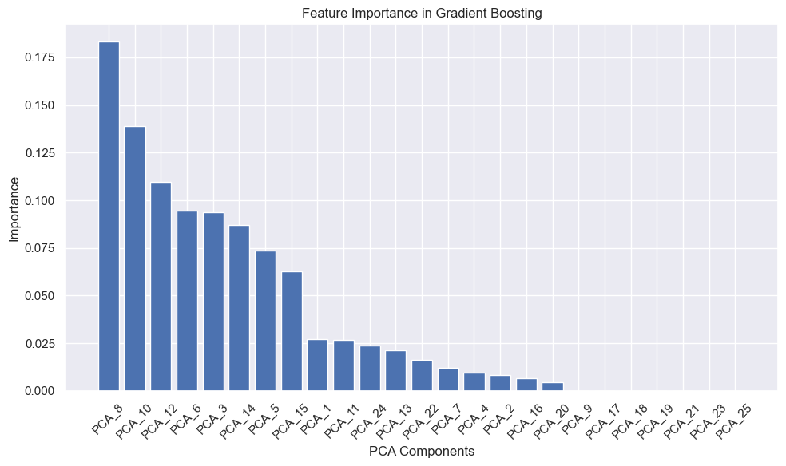

```python
# Get feature importance from the XGBoost model
xgb_feature_importance = xgb_model.feature_importances_

# Create a DataFrame for better readability
xgb_importance_df = pd.DataFrame({
    'Feature': [f'PCA_{i+1}' for i in range(X_train.shape[1])],
    'Importance': xgb_feature_importance
}).sort_values(by='Importance', ascending=False)

# Display the importance DataFrame
print(xgb_importance_df)

# Visualize feature importance
plt.figure(figsize=(10, 6))
plt.bar(xgb_importance_df['Feature'], xgb_importance_df['Importance'], align='center')
plt.xlabel('PCA Components')
plt.ylabel('Importance')
plt.title('Feature Importance in Gradient Boosting')
plt.xticks(rotation=45)
plt.tight_layout()
plt.show()
```

# Gradient Boosting Feature Importance Analysis

From the bar chart and table of feature importance, here are the observations:

# Bonus Task - Clusters Analysis

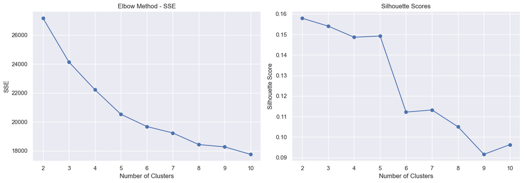

```python
# Define the model

# Elbow Method
sse = []
silhouette_scores = []
for k in range(2, 11):
    kmeans = KMeans(n_clusters=k, random_state=1)
    kmeans.fit(X_pca)
    sse.append(kmeans.inertia_)
    silhouette_scores.append(silhouette_score(X_pca, kmeans.labels_))

# Plotting Elbow and Silhouette Scores
plt.figure(figsize=(14, 5))

plt.subplot(1, 2, 1)
plt.plot(range(2, 11), sse, marker='o')
plt.title('Elbow Method - SSE')
plt.xlabel('Number of Clusters')
plt.ylabel('SSE')

plt.subplot(1, 2, 2)
plt.plot(range(2, 11), silhouette_scores, marker='o')
plt.title('Silhouette Scores')
plt.xlabel('Number of Clusters')
plt.ylabel('Silhouette Score')

plt.tight_layout()
plt.show()
```

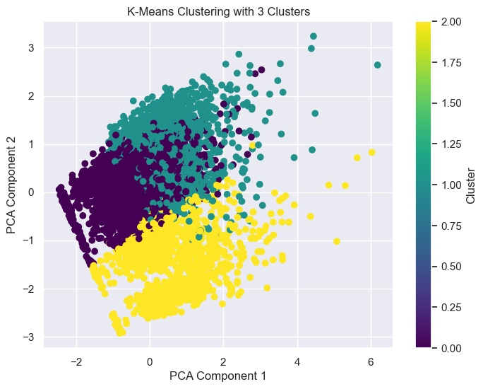

```python
# Assuming 3 clusters based on visual inspection (adjust based on results)
optimal_clusters = 3
kmeans = KMeans(n_clusters=optimal_clusters, random_state=1)
kmeans_labels = kmeans.fit_predict(X_pca)

# Visualizing Clusters
plt.figure(figsize=(8, 6))
plt.scatter(X_pca[:, 0], X_pca[:, 1], c=kmeans_labels, cmap='viridis')
plt.title(f'K-Means Clustering with {optimal_clusters} Clusters')
plt.xlabel('PCA Component 1')
plt.ylabel('PCA Component 2')
plt.colorbar(label='Cluster')
plt.show()
```

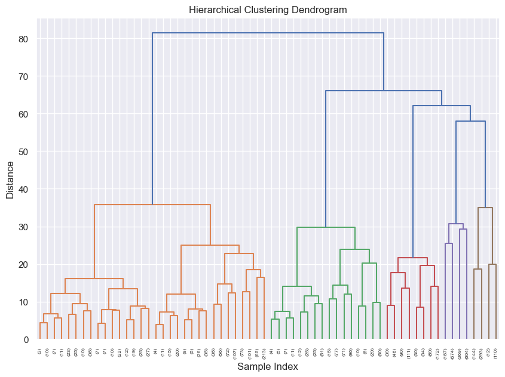

```python
from scipy.cluster.hierarchy import dendrogram, linkage

# Perform Hierarchical Clustering
Z = linkage(X_pca, method='ward')

# Plot the Dendrogram
plt.figure(figsize=(10, 7))
dendrogram(Z, truncate_mode='level', p=5)
plt.title('Hierarchical Clustering Dendrogram')
plt.xlabel('Sample Index')
plt.ylabel('Distance')
plt.show()
```

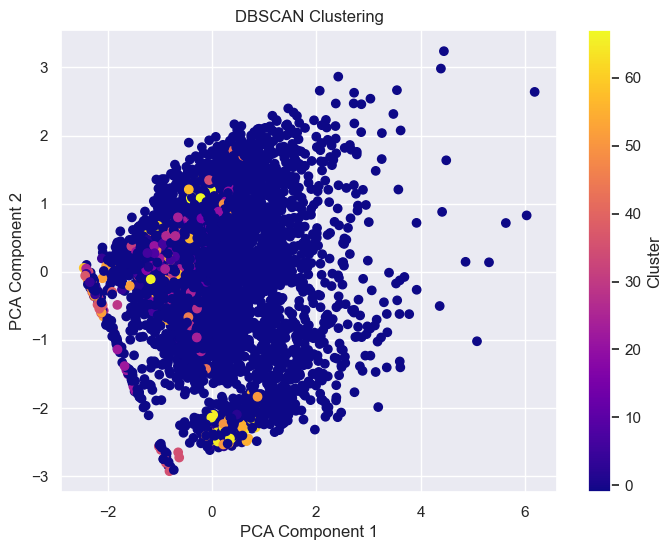

```python
# Apply DBSCAN
dbscan = DBSCAN(eps=0.5, min_samples=5)
dbscan_labels = dbscan.fit_predict(X_pca)

# Visualize DBSCAN Results
plt.figure(figsize=(8, 6))
plt.scatter(X_pca[:, 0], X_pca[:, 1], c=dbscan_labels, cmap='plasma')
plt.title('DBSCAN Clustering')
plt.xlabel('PCA Component 1')
plt.ylabel('PCA Component 2')
plt.colorbar(label='Cluster')
plt.show()
```

# Observations:

Clusters:

The colors represent the clusters identified by DBSCAN. Different shades (e.g., yellow, red, purple) indicate distinct clusters. Some clusters are tightly packed, while others are more scattered, reflecting the flexibility of DBSCAN in identifying arbitrary shapes. Noise:

Points in dark blue likely represent noise or outliers that DBSCAN could not assign to any cluster. Scalability with PCA:

Using the first two PCA components allows the clusters to be visualized clearly, helping to assess DBSCAN’s effectiveness. Key Questions: Did DBSCAN capture meaningful structures in the data?

Check if the clusters align with any known labels or logical groupings. What are the optimal eps and min_samples values?

Adjusting eps (neighborhood radius) and min_samples can reveal hidden clusters or refine the existing ones. Does noise represent true outliers?

Investigating the characteristics of noise points might uncover interesting insights. Next Steps: Would you like to:

Tweak eps and min_samples for DBSCAN to refine clusters? Compare these clusters with the actual class labels (if available)? Proceed with further clustering analysis or integrate these findings into your notebook?

```python
# Try different combinations of eps and min_samples
eps_values = np.linspace(0.1, 1.0, 10)
min_samples_values = [3, 5, 10, 15]

# Store results
dbscan_results = []

for eps in eps_values:
    for min_samples in min_samples_values:
        dbscan = DBSCAN(eps=eps, min_samples=min_samples)
        labels = dbscan.fit_predict(X_pca)
        n_clusters = len(set(labels)) - (1 if -1 in labels else 0)
        n_noise = list(labels).count(-1)
        dbscan_results.append((eps, min_samples, n_clusters, n_noise))

# Convert to DataFrame for better visualization
import pandas as pd
dbscan_results_df = pd.DataFrame(dbscan_results, columns=['eps', 'min_samples', 'n_clusters', 'n_noise'])

# Display the top results
dbscan_results_df.sort_values(by='n_clusters', ascending=False).head(10)
```

|  | eps | min_samples | n_clusters | n_noise |
| --- | --- | --- | --- | --- |
| 20 | 0.6 | 3 | 216 | 2845 |
| 24 | 0.7 | 3 | 210 | 2295 |
| 16 | 0.5 | 3 | 190 | 3465 |
| 28 | 0.8 | 3 | 174 | 1871 |
| 32 | 0.9 | 3 | 165 | 1602 |
| 36 | 1.0 | 3 | 149 | 1374 |
| 12 | 0.4 | 3 | 136 | 3838 |
| 8 | 0.3 | 3 | 92 | 4252 |
| 29 | 0.8 | 5 | 86 | 2453 |
| 25 | 0.7 | 5 | 85 | 3046 |

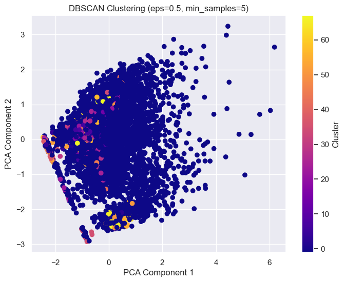

```python
# Apply DBSCAN with the best parameters
best_eps = 0.5  # Replace with your chosen value
best_min_samples = 5  # Replace with your chosen value

dbscan_optimized = DBSCAN(eps=best_eps, min_samples=best_min_samples)
labels_optimized = dbscan_optimized.fit_predict(X_pca)

# Visualize the optimized clusters
plt.figure(figsize=(8, 6))
plt.scatter(X_pca[:, 0], X_pca[:, 1], c=labels_optimized, cmap='plasma')
plt.title(f'DBSCAN Clustering (eps={best_eps}, min_samples={best_min_samples})')
plt.xlabel('PCA Component 1')
plt.ylabel('PCA Component 2')
plt.colorbar(label='Cluster')
plt.show()
```

```python
# Example: Adding DBSCAN labels to the dataset
dbscan = DBSCAN(eps=0.5, min_samples=5)
labels = dbscan.fit_predict(X_pca)
data['Cluster'] = labels
```

```python
# Convert the 'Cluster' column to numeric (if not already)
data['Cluster'] = pd.to_numeric(data['Cluster'], errors='coerce')

# Group by clusters and calculate summary statistics
cluster_summary = data.groupby('Cluster').mean(numeric_only=True)
print(cluster_summary)

# Check cluster sizes
cluster_sizes = data['Cluster'].value_counts()
print(cluster_sizes)
```

```
               age  website_visits  time_spent_on_website  \
Cluster
-1       45.225628        3.780151             780.633417
 0       57.360000        2.880000             285.760000
 1       53.187500        2.687500             236.718750
 2       21.125000        2.000000             168.375000
 3       56.666667        0.000000               0.000000
...            ...             ...                    ...
 63      57.200000        3.200000             294.400000
 64      20.714286        2.571429             152.857143
 65      21.400000        1.600000             275.000000
 66      53.400000        1.400000             213.200000
 67      56.800000        2.600000            1550.600000

         page_views_per_visit    status
Cluster
-1                   2.713568  0.298744
 0                   2.000000  0.040000
 1                   2.000000  0.187500
 2                   2.000000  0.125000
 3                   0.000000  0.000000
...                       ...       ...
 63                  2.000000  0.000000
 64                  2.000000  0.142857
 65                  2.000000  0.000000
 66                  2.000000  0.000000
 67                  2.000000  0.200000

[69 rows x 5 columns]
Cluster
-1     3980
 1       32
 24      32
 6       27
 0       25
       ...
 48       5
 33       5
 45       5
 9        5
 65       5
Name: count, Length: 69, dtype: int64
```

# 1. Cluster Characteristics

The Cluster column includes both noise (-1) and meaningful clusters. Key observations:

Cluster 3: Represents users who spent no time on the website, likely an outlier group.

2. Cluster Sizes

Dominant Noise Cluster: The noise cluster (-1) dominates, which is expected in DBSCAN when the data has outliers or doesn't form dense groups.

# Actionable Advice

1. Optimize Website Engagement

Encourage longer but focused website interaction:

Optimize the website for key content (e.g., program benefits, testimonials). Implement call-to-action (CTA) triggers after specific engagement thresholds (e.g., after 2–3 pages or 250 seconds).

Increase Website Visits:

Clusters with more visits (e.g., Cluster 58) show higher enrollment. Strategies: Use email campaigns or retargeting ads to bring users back to the site. Incentivize multiple visits through limited-time offers, educational resources, or interactive content. 2. Personalize Marketing Based on Age Segment by Age Groups:

Younger audiences: Use social media ads with dynamic, quick content (videos, infographics). Older audiences: Focus on email marketing and emphasize program credibility, benefits, and testimonials. 3. Address Non-Engaged Users (Cluster 3)

Users with zero time spent on the website (Cluster 3) have no enrollment.

Strategies: Follow-up Email Campaigns: Target users who visited but didn’t interact with content. Highlight program advantages, free trials, or success stories. Simplify the website experience to reduce barriers to engagement. 4. Incentivize Specific Behaviors Rewards for Registration: Offer small incentives (e.g., discounts, free resources) to encourage users to register during their first or second visit. Gamify Engagement: Use interactive quizzes or assessments to keep users engaged and nudge them toward enrollment. 5. Focus on Clusters with High status (e.g., Cluster 58) Replicate the behavior of successful clusters: High website visits: Encourage multiple site interactions. Moderate time spent: Avoid overwhelming users with excessive information. Next Steps Develop a Marketing Strategy:

Use cluster and feature insights to craft campaigns targeting specific behaviors and demographics. Test Engagement Changes:

Implement the above strategies and monitor metrics like time spent, page views, and status. Refine the Dataset:

Investigate users in noise (-1) to see if they can be nudged toward higher engagement.

# Clustering: Unsupervised Learning

Strengths: Behavioral Grouping:

Clustering identified natural patterns in user behavior that were not influenced by the target variable (status). For example, DBSCAN uncovered groups of users with distinct engagement levels (e.g., noise users, zero-interaction users, high-engagement clusters). Exploration of Outliers:

Clusters provide insights into user subgroups independently of status, potentially uncovering hidden segments that supervised models might overlook. How They Complement Each Other From Prediction to Understanding:

Tree models predict who is likely to enroll but may not explain the subgroups within the data. Clustering complements by revealing behavioral archetypes (e.g., disengaged users, repeat visitors) that might otherwise remain hidden. Cluster Analysis Informs Tree Models:

Cluster characteristics (e.g., engagement metrics for high-status clusters) can be fed back into supervised models: Example: Add a "Cluster" feature as a categorical variable in tree-based models to incorporate user subgroup insights into predictions. Unsupervised Validation:

Clustering can validate or challenge supervised results: For example, clusters with high enrollment rates align with features like moderate time spent and repeat visits, reinforcing what tree models indicated. Targeting Specific Groups:

Clustering helps design personalized strategies: Noise groups (-1) can be re-engaged with tailored campaigns. High-engagement clusters can be nurtured with specific offers.

# Cluster Analysis Adds Value By:

Providing Context:

While tree models tell us who is likely to enroll, clustering helps us understand why by grouping users based on behavior patterns. Exploring the "Noise":

Noise clusters (-1) highlight users who might otherwise be ignored in a predictive model but represent potential opportunities for improvement. Offering Unbiased Insights:

Tree models focus on the target variable, while clustering looks at the data holistically, uncovering hidden relationships. When to Use Each Approach

Tree-Based Models: Use when you need direct predictions (e.g., predict which users will enroll). Use feature importance to drive targeted strategies.

Clustering: Use when exploring user subgroups and uncovering patterns that might inform new strategies (e.g., identifying disengaged vs. high-potential users).

Use as a complementary analysis to refine decision-making.

# Insights Gained

1. Key Features Driving Enrollment (status)

From tree-based models:

Identified subgroups of users: High engagement, high status clusters (e.g., Cluster 58 with ~66% enrollment). Noise cluster (-1), representing disengaged or outlier users (~30% enrollment). Behavior patterns suggest focusing on retargeting noise users and replicating the behaviors of high-performing clusters. Cluster Characteristics:

Revealing Behavioral Archetypes: Uncovered patterns that tree models could not, such as distinct subgroups within users who visited the website but did not enroll. Identifying Opportunities: Noise points (-1) highlight a target group for engagement campaigns. Validation: Aligning clusters with high status values to supervised results reinforced findings (e.g., importance of website engagement). Why Tree-Based Models and Clustering Outperform Linear Regression

1. Non-Linear Relationships

Tree-based models excel at capturing non-linear relationships between features and status: Example: Moderate time spent on the website correlates with higher enrollment, while excessive time does not—a pattern linear regression cannot model effectively. 2. Feature Interactions Tree models capture interactions between features: Example: The combination of website visits and time spent on the site jointly drives enrollment. Linear regression treats these independently, losing this synergy. 3. Class Imbalance Linear regression assumes a continuous, normally distributed target variable. However: The status variable is binary (0 or 1), and tree-based models naturally handle classification tasks with class imbalance. 4. Clustering Beyond Prediction Clustering identifies behavioral subgroups that linear regression cannot: Example: Identifying a cluster of users with zero interaction or over-engagement helps target interventions. Final Takeaways Tree Models:

Provided actionable insights into which features drive enrollment. Enabled direct prediction of status with high accuracy and interpretability. Clustering:

Added depth to the analysis by uncovering behavioral patterns and highlighting outliers. Complemented supervised methods by offering independent validation. Better Than Linear Regression:

Captures complex, non-linear relationships and interactions between features. Handles binary classification and class imbalance more effectively. Provides deeper insights into user behavior through clustering. Next Steps Implement targeted interventions based on cluster characteristics (e.g., retarget noise users, replicate high-engagement clusters). Incorporate cluster labels into tree models for enhanced predictions. Test marketing strategies (e.g., email campaigns, incentives) to improve website engagement and enrollment.